# Model Complexity, Training Error, and Test Error

Lisa Stuart

March 16, 2016

# Model Complexity, Training Error, and Test Error

- One of the measures of model complexity is the number of variables that are used to fit a model.
- As we fit more complex models - e.g. models with more variables - the training error will always decrease
- But the test error might not necessarily decrease
- The number of variables in the model is not the only - or even best - way to quantify model complexity

Let’s see an example where we are just going to simulate some data to look at:

This code creates a training set with a 100 x 100 matrix of random normal variables (variables from a normal distribution, here with a mean 0 and standard deviation 1) with 100 columns. Then we’ll print the first 6 rows and the first 10 columns to get an idea of what the values look like.

```r
xtr = matrix(rnorm(100*100), ncol = 100)
xtr[1:6, 1:10]
```

```
##             [,1]       [,2]       [,3]        [,4]       [,5]       [,6]
## [1,]  0.98157544  0.2969352 -1.2934526  0.45877662  0.5359189  0.8679641
## [2,]  0.42579358 -0.7788515 -0.8102257  0.69326968 -0.8646697 -0.3920435
## [3,]  1.93925799  0.7304038  0.9911007  0.56686780 -2.4298726 -0.5539404
## [4,]  0.45626763  1.9656678 -0.2797041 -2.01718870 -1.5198460 -0.1116495
## [5,]  0.02766547  1.7662639  0.9142776  0.03892866  0.5947038 -0.6356759
## [6,] -0.48575933 -0.1792620  0.2361554  1.45277824  0.2838803 -0.3590385
##             [,7]        [,8]        [,9]        [,10]
## [1,] -0.85205624  1.68855051  2.04758622 -0.188565640
## [2,]  0.30552817  0.38335585 -0.13294107  0.190488110
## [3,]  0.36406012  0.03552727  0.91761446 -1.501326323
## [4,] -0.29249827 -1.00205345  0.57702740  0.007848226
## [5,] -0.95976236 -0.11383210 -0.65888105  0.686762745
## [6,]  0.07447535  2.06203482 -0.03660565  1.111594113
```

As you probably noticed, the values randomly bounce around 0, mostly between -1 and 1, with occasional values more extreme that represent values further away from the mean than 1 standard deviation.

Next, let’s create a test or validation set with a 100,000 x 100 matrix of random normal variables, again with a mean of 0 and standard deviation equal to 1 with 100 columns.

```r
xte = matrix(rnorm(100000*100), ncol = 100)
```

Create a vector of beta values with 10 (good) signals and 90 junk variables.

```r
beta = c(rep(1,10), rep(0,90))
beta[1:15]
```

```
##  [1] 1 1 1 1 1 1 1 1 1 1 0 0 0 0 0
```

Create a vector of 100 response (y) variables for the training data and 100,000 for the test data.

```r
ytr = xtr%*%beta + rnorm(100)
ytr[1:5]
```

```
## [1]  3.315371 -0.698006  1.009910 -2.037100  2.133840
```

```r
yte = xte%*%beta + rnorm(100000)
yte[1:5]
```

```
## [1]  2.7111638 -1.3537810  0.1767983  5.7065703 -3.2596743
```

Instantiate NULL values for R squared, training error, and test error to be used in the function that follows.

```r
rsq = trainerr = testerr = NULL
```

Function to fit a linear model to the training data and then calculates R squared and estimates both training error and test error.

```r
for(i in 2:100) {
    mod = lm(ytr ~ xtr[, 1:i]) # fit a linear model to train to include all rows and columns 1 to i
    rsq = c(rsq, summary(mod)$r.squared) # get R^2 from model summary using $ operator
    beta = mod$coef[-1] # only grab slope coefficient estimate
    intercept = mod$coef[1] # grab intercept coefficient estimate
    trainerr = c(trainerr, mean((xtr[, 1:i]%*%beta + intercept - ytr)^2)) # estimate training error
    testerr = c(testerr, mean((xte[ , 1:i]%*%beta + intercept - yte)^2)) # estimate test error
}
```

Recalling that only 10 variables are related to the response and that the other 90 are just junk, here are plots (with y on the log scale) that show that as the number of variables increases: R Squared increases, Training error decreases, and Test error is lowest only when the signal variables are in the model

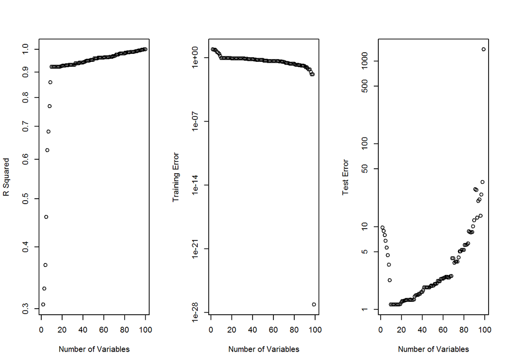

## Bias and Variance

- As model complexity increases, the bias of beta_hat - the average difference between the true beta and beta_hat, if we were to repeat the experiment a huge number of times - will decrease.
- But as complexity increases, the variance of beta_hat - the amount by which the beta_hats will differ across experiments - will increase.
- The test error depends on both the bias and variance:

  ```
  Test Error = Bias^2 + Variance
  ```

- There is a bias-variance trade-off. We want a model that is sufficiently complex as to have not too much bias, but not so complex that it has to much variance.

## Overtfitting

- Fitting an overly complex model - a model that has too much variance - is known as overfitting.
- When p is approximately equal to n, we must work hard to avoid overfitting
- In particular, we must rely not on training error, but on test error, as a measure of model performance.
- How can we estimate the test error?
1. The validation set approach.
2. Leave-one-out cross-validation
3. K-fold cross-validation